# The Most Worth Noting Source of Infection About COVID-19 Cases in Toronto is Close Contact

Yijia Liu

2020-09-20T21:13:14-05:00

Abstract

COVID-19 became the heatest topic around 2020, and we need to determine the source of infection to prevent further outbreak in Toronto and to go through this period together. In this paper, we explore the *About COVID-19 Cases in Toronto* dataset to figure out some important **Source of Infection** in Toronto. We find that **Close contact** has the highest count for about **6500** cases among the city. Our findings have implications for further prevention and protection for citizens in Toronto.

# Introduction

Coronavirus disease (COVID-19) is an infectious disease caused by a newly discovered coronavirus (WHO, 2020). Now, 32,784,889 confirmed cases of COVID-19 have been reported in 213 countries and regions around the world (WORLDOMETER, 2020).Toronto health officials announced the first case of COVID-19 in Canada on January 25, after that, the COVID-19 cases increases rapidly in Canada (Thomas, 2020). There are about 17,872 cases in Toronto up until September 26th, 2020 and the number is increasing everyday (City of Toronto, 2020). As the result, we need to take this case seriously. For people who live in Toronto, they need to know how should they deal with this situation and stay safe. One way in my opinion is to find out the most possible source of infection in Toronto because the result can be a reference for citizens to know what are the latent threats to their health and to avoid further infections for themselves.

I selected the data set of COVID-19 cases in Toronto from the *Toronto Open Data* to find out which infection has the strongest relationship with COVID-19 cases. I drew a bar graph that included a list of infection sources related to the case. Each category shows the number of cases related to a particular infection, which is an obvious conclusion. According to the bar graph, I found that **Close Contact** has the highest count in **6500** cases. This means that most observers are in close contact with confirmed or probable COVID-19 cases. Code and data supporting this analysis is available at: https://github.com/LesleyyijiaLiu/The-Most-Worth-Noting-Source-of-Infection-About-COVID-19-Cases-in-Toronto-is-Close-Contact

From this graph, we can find that remember that the most effective way to protect yourself from COVID-19 is to stay at home and avoid gathering. Using this chart as a reference, people in Toronto can more clearly know what to avoid, what to remember for further protection, and stay away from rumours. One limitation of this data set is that the figures of *Toronto Public Data* may be different from figures published elsewhere because the data was extracted at different times and come from different sources, which means it is difficult to determine which figure may be the most precise one.

# About the Dataset

In the context of the evolving global epidemic, Toronto’s public health department is responding to the ongoing COVID-19 outbreak. This data set contains demographic, geographic information and severity information of all confirmed and probable cases that have been reported to and managed by Toronto Public Health since the first case was reported in January 2020. These include sporadic (occurring in the community) and fulminant cases-related. Data is extracted from the Provincial Infectious Disease Reporting System (iPHIS) and Toronto’s customized COVID-19 Case Management System (CORES), and combined for reporting. Each row summarizes the information of a case.

## Data summary

Data summary

| Name | data |
| --- | --- |
| Number of rows | 17872 |
| Number of columns | 18 |
| _______________________ |  |
| Column type frequency: |  |
| character | 16 |
| numeric | 2 |
| ________________________ |  |
| Group variables | None |

**Variable type: character**

| skim_variable | n_missing | complete_rate | min | max | empty | n_unique | whitespace |
| --- | --- | --- | --- | --- | --- | --- | --- |
| Outbreak Associated | 0 | 1 | 8 | 19 | 0 | 2 | 0 |
| Age Group | 0 | 1 | 3 | 14 | 0 | 10 | 0 |
| Neighbourhood Name | 0 | 1 | 3 | 35 | 0 | 141 | 0 |
| FSA | 0 | 1 | 3 | 3 | 0 | 97 | 0 |
| Source of Infection | 0 | 1 | 6 | 25 | 0 | 8 | 0 |
| Classification | 0 | 1 | 8 | 9 | 0 | 2 | 0 |
| Episode Date | 0 | 1 | 10 | 10 | 0 | 217 | 0 |
| Reported Date | 0 | 1 | 10 | 10 | 0 | 212 | 0 |
| Client Gender | 0 | 1 | 4 | 11 | 0 | 5 | 0 |
| Outcome | 0 | 1 | 5 | 8 | 0 | 3 | 0 |
| Currently Hospitalized | 0 | 1 | 2 | 3 | 0 | 2 | 0 |
| Currently in ICU | 0 | 1 | 2 | 3 | 0 | 2 | 0 |
| Currently Intubated | 0 | 1 | 2 | 3 | 0 | 2 | 0 |
| Ever Hospitalized | 0 | 1 | 2 | 3 | 0 | 2 | 0 |
| Ever in ICU | 0 | 1 | 2 | 3 | 0 | 2 | 0 |
| Ever Intubated | 0 | 1 | 2 | 3 | 0 | 2 | 0 |

**Variable type: numeric**

| skim_variable | n_missing | complete_rate | mean | sd | p0 | p25 | p50 | p75 | p100 | hist |
| --- | --- | --- | --- | --- | --- | --- | --- | --- | --- | --- |
| _id | 0 | 1 | 152582.50 | 5159.35 | 143647 | 148114.75 | 152582.5 | 157050.25 | 161518 | ▇▇▇▇▇ |
| Assigned_ID | 0 | 1 | 9026.35 | 5248.05 | 1 | 4482.75 | 8984.5 | 13529.25 | 18202 | ▇▇▇▇▇ |

# Graph of Source of Infection About COVID-19 Cases in Toronto

In this paper, I’m going to look at different **Source of Infection** in COVID-19 Cases in Toronto. By looking up those infections as a reference, we can have a clear idea about what should we avoid and what should we remember for the further protection as well as avoid those rumors that threat people with no reason.

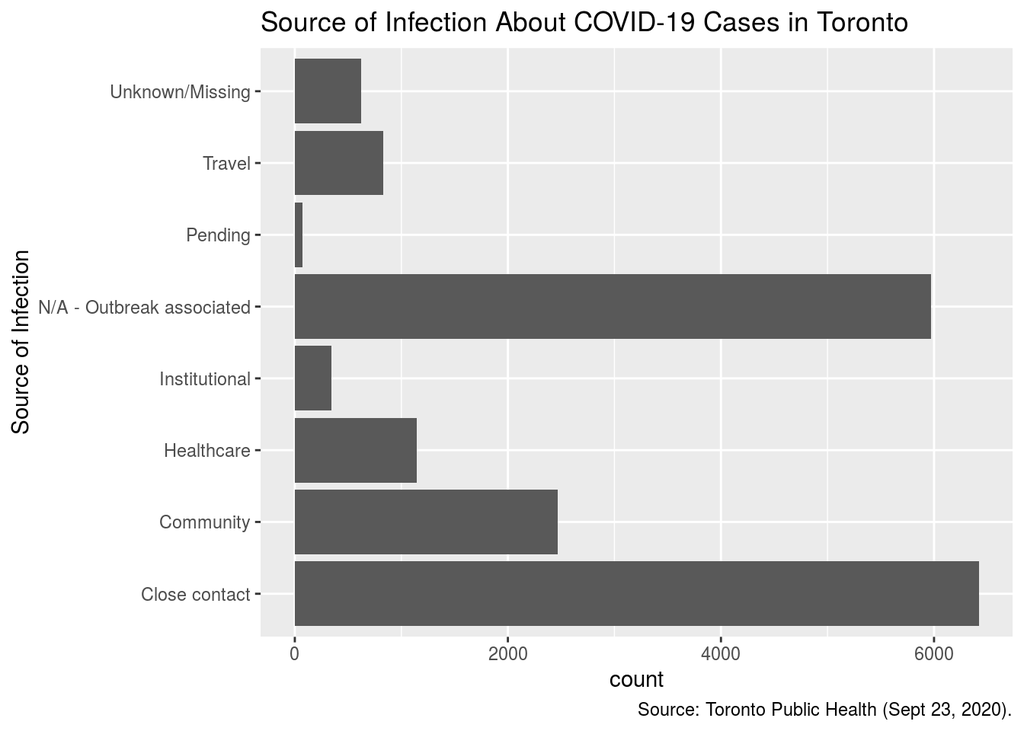

# Discussion

The bar plot I drew shows the different sources of infection about 17872 COVID-19 cases in Toronto and how many cases does each source contain.

From the graph we can see **Close contact** has the highest count for about **6500** cases. Which means most of the observants was in close contact with a confirmed or probable COVID-19 case, for example they were reside in the same household with a confirmed or probable COVID-19 case. In this case, it is a warning for us to remember the most efficient way to protect ourselves and others is to stay at home and avoid gather around.

Something surprised is that **N/A** is also a high-count-category compare to other source of infection, which contains about **6000** cases in Toronto. It may be reasonable because all the cases included in **N/A** section are related to **outbreak period**, in that period, it may be hard to determine which source exactly cause the infection.

Moreover, it is worth noticing that there are also few cases, which are categorized as **Unknown/Missing** or **Pending**, which means source of infection does not identified or missing or information on source of infection is pending. In this severe period, it is a good habit to protect others that when people go out they remember where they go and who they contact with. This habit may make life easier for the government and public health institution to target the possible infected area and control a further coming outbreak as soon as possible.

As the public health investigation of the reported cases and the continuous quality improvement plan progress, the data in *Toronto Open Data* may change, and other cases will continue to be reported. It means none of the sources of infection is less threatening than others, no matter how many cases does one kind of infection has, people should be aware of all of them and try their best to avoid the infections.

## Weaknesses

The numbers that *Toronto Open Data* have may be different from those published elsewhere because the data was extracted at different times and come from different sources, which means it would be hard to decide which number may be the most precise one.

Another limitation would be the correctness of classification. Since the source of infection may be overlapped, people may feel difficult to figure out what source exactly cause their infection to COVID-19. For example, people who are in **Healthcare setting** such as, family physician, dentist, ophthalmologist, sports doctor, may also be categorized in **Institutional setting** because they may as well work in long-term care homes, acute care hospitals, complex case hospitals, special-care facilities, retirement homes, rehabilitation hospitals.

# References

-R Core Team (2020). R: A language and environment for statistical computing. R Foundation for Statistical Computing, Vienna, Austria. URL https://www.R-project.org/.

-JJ Allaire and Yihui Xie and Jonathan McPherson and Javier Luraschi and Kevin Ushey and Aron Atkins and Hadley Wickham and Joe Cheng and Winston Chang and Richard Iannone (2020). rmarkdown: Dynamic Documents for R. R package version 2.3. URL https://rmarkdown.rstudio.com.

- Wickham et al., (2019). Welcome to the tidyverse. Journal of Open Source Software, 4(43), 1686, https://doi.org/10.21105/joss.01686

-H. Wickham. ggplot2: Elegant Graphics for Data Analysis. Springer-Verlag New York, 2016.

-Hadley Wickham, Romain Fran?ois, Lionel Henry and Kirill Müller (2020). dplyr: A Grammar of Data Manipulation. R package version 1.0.2. https://CRAN.R-project.org/package=dplyr

-Elin Waring, Michael Quinn, Amelia McNamara, Eduardo Arino de la Rubia, Hao Zhu and Shannon Ellis (2020). skimr: Compact and Flexible Summaries of Data. R package version 2.1.2. https://CRAN.R-project.org/package=skimr

-Sharla Gelfand (2020). opendatatoronto: Access the City of Toronto Open Data Portal. R package version 0.1.3. https://CRAN.R-project.org/package=opendatatoronto

-Toronto Public Health (Sept 23, 2020). https://open.toronto.ca/dataset/covid-19-cases-in-toronto/

-Coronavirus disease (COVID-19). (n.d.). Retrieved September 26, 2020, from https://www.who.int/emergencies/diseases/novel-coronavirus-2019

-Countries where COVID-19 has spread. (n.d.). Retrieved September 26, 2020, from https://www.worldometers.info/coronavirus/countries-where-coronavirus-has-spread/

-Thomas, D., & Nair, A. (2020, January 25). Canada identifies first case of coronavirus. Retrieved September 26, 2020, from https://www.reuters.com/article/us-china-health-canada-idUSKBN1ZO0T9

-City of Toronto. (2020, September 25). COVID-19. Retrieved September 26, 2020, from https://www.toronto.ca/home/covid-19/